# Compute HHI and FA

2026 06 08 17:13

# What this file does (chunk summary)

1. {setup} — Load libraries, define helpers (grepout, geovars, GeoLevel)
2. {read irp5 file} — Load irp5.qs
3. {fraction affected for all years} — Loop yr 8–22: compute duration, monthly income, SubMW, FA/FAe/FAMP/FAeMP at firm and establishment levels. Save FA{yr}.qs, AggregateSummary.qs
4. {create FA panel} — Stack yearly FA → FAD.qs
5. {industry code for ag} (eval=F) — One-time: classify agriculture firms → TaxrefnoOfAgri.qs
6. {faa and Fadata are first lines of FAD in each year} — Collapse to establishment-year, filter duration and agriculture → FAOfAgri.qs, fadataUniqueEntries.qs
7. {copy FAD and derived files to saveddata} (eval=F) — Copy outputs
8. {descriptive stats FA and jobs} — Tables of aggregate FA (all industries + agriculture)
9. {plot FAs by size} — Density of FA by firm size
10. {plot FAs by jobs employment} — Density of FA in jobs vs employment
11. {plot number of agri jobs taxyear 2012-2020} — Histogram of ag establishment size
12. {agri Jobs by firm age} (eval=F) — Bar chart: ag jobs by incumbents vs entrants
13. {plot FA in agri 2012-2020} — Density of FA by tax year
14. {plot FA of agri} — Boxplot of FA by tax year, Exposed/Unexposed
15. {define irp5M by location granularity} — Classify location completeness, create irp5M/L/D/P panels, filter agriculture → irp5Ma.qs
16. {copy irp5M and derived files to saveddata} (eval=F) — Copy outputs
17. {hhi} — Compute labour market shares, HHI, nHHI at 4 geo levels. Save ShareHHI{yr}.qs. Plot HHI 2012 vs 2013
18. {create LShare panel} — Stack yearly HHI → LShareHHI.qs
19. {LSa is LS of agri only} — Filter HHI to agriculture → HHIAgriRows.qs
20. {copy LShareHHI.qs HHIAgriRows.qs to saveddata} (eval=F) — Copy outputs
21. {further checks on shares} (eval=F) — Ad hoc checks (stale column names)
22. {plot HHI by year} (eval=F) — Density of HHI by year

# What we do in the project

1. Create merged panel using stata: “Data file”
   - Use the same definitions as Michael’s codes
   - But include `imp_mic_sic7_3d == 16` industry
   - Done in other do file
   - Save Data file in tsv format to read in R
2. Compute HHI using CIT-IRP5 at various levels: “HHI file”
   - Use CIT-IRP5_2012 HHI in 2012
   - Verify if counts are not erroneous
3. “Analysis file” = Data file (panel 2009-2022) + HHI file
   - Merge at various levels
   - Need main place level analysis for larger statistical power
4. Descriptive statistic
5. Hypothesis testing
   - % Employment change = a + b1*FA + b2*HHI + b3*(FA*HHI) + FEs + e
   - Test b3 > 0 labor market power mitigates disemployment impacts
   - Expect b1<0 or b1 = 0
   - No prior for the sign of b2

# Setup

```r
library(qs); library(data.table); library(ggplot2)
library(rmarkdown); library(fixest)
library(knitr); library(tufte)
library(litedown)
library(fasttime)
library(anytime)
#### Set chunk options in litedown
litedown::reactor(
    eval = TRUE
  , echo = TRUE
  , time = TRUE   # record elapsed time of execution
)
options(htmltools.dir.version = FALSE, width = 100)
#### threads
MaxCores <- parallel::detectCores()
DTThreads <- MaxCores - 1
setDTthreads(threads = DTThreads)
setFixest_nthreads(nthreads = DTThreads, save = TRUE)
#### ggplot theme
ThisTheme <- ggplot2::theme(
   axis.text.x = element_text(angle = 90, vjust = .5, hjust = .5),
   axis.text.y = element_text(size = 12),
   axis.title = element_text(size = 10),
   strip.text.x = element_text(color = "blue", size = 8,
     margin = margin(0, 1.25, 0, 1.25, "cm")),
   strip.text.y = element_text(color = "blue", size = 8,
     margin = margin(1.5, 0, 1.5, 0, "cm")),
   panel.spacing.x = unit(c(.1), units = "cm"),
   panel.spacing.y = unit(.1, units = "cm")
)
ThisThemeEnd <- ThisTheme + ggplot2::theme(legend.position="bottom")
#### invalidate cache when the tufte version changes
knitr::opts_chunk$set(
  tidy = FALSE, cache.extra = packageVersion('tufte'),
  margin_references = TRUE,
  attr.source = ".r .line-numbers",
  #### remove leading hashes in html output
  comment = "",
  echo = T, cache = F, eval = T,
  class.source = "SeiroBenign", class.output = "SeiroLightGreen"
  )
grepout <- function(str, x)
  # returns element of match (not numbers)
  x[grep(str, x, perl = T)]
table0 <- function(x) table(x, useNA = "ifany")
#### mask_dots: replace every char except positions in `keep` with ".".
#### Used to anonymise taxrefno / uid in display-only prints (not in keys or joins).
mask_dots <- function(x, keep = c(3, 6, 7, 8, 11)) {
  x <- as.character(x)
  n <- nchar(x)
  out <- strrep(".", n)
  for (k in keep) {
    m <- !is.na(x) & n >= k
    substr(out[m], k, k) <- substr(x[m], k, k)
  }
  out
}
read.tablev <- function(fn, quotemark = "", headertrue = TRUE,
  blskip = TRUE, mat = F, ...)
{
  x <- read.table(fn, sep = "\t", header = headertrue, blank.lines.skip = blskip,
        quote = quotemark, na.strings = "", ...)
  if (is.null(dim(x)) | nrow(x) == 1)
  {
    cn <- names(x)
    dim(x) <- c(1, length(x))
    colnames(x) <- cn
  }
  if (mat) x <- as.matrix(x)
  return(x)
}
write.tablev <- function(x, fn, colnamestrue = TRUE, rownamestrue = FALSE,
nastrings = "", ...)
  write.table(x, fn, sep = "\t", quote = FALSE,
        row.names = rownamestrue, col.names = colnamestrue, na = nastrings, ...)
GeoLevel <- c("Prv", "Dis", "Loc", "Mai")
geovars <- c("busprov_geo", "busdistmuni_geo",
  "buslocmuni_geo", "busmainplc_geo")
```

- FA does not require location info in theory, but it does in practice
  - If the establishment ID `payereferenceno` is not corrupt, location info is not necessary
  - But we cannot rely on `payereferenceno`, because establishments at different locations share the same `payereferenceno`, probably firms and SARS did not care to assign unique values for each establishments
  - So we must rely on location info to aggregate employees/jobs at the establishment level of a specific location
- HHI requires location info, so we use `irp5M` that have information of Main Place
  - Whenever location information is updated, we need to compute HHI
  - To update location information, need to update irp5.qs → irp5M.qs → LShareHHI.qs

# Fraction affected

1. Use IRP5 to count total number of workers, number of affected, FA = affected/total for all years
   - PropToMW := IncomeMonth/2274: income/MW ratio
   - SubMW := as.integer(PropToMW < 1 & IncomeMonth > 0)

   Firm level: by = .(Txrf, taxyear)

   Establishment level: by = c(“Txrf”, geovars, “taxyear”)
   - NumSubMW, NumSubMWMP := as.integer(sum(SubMW==1L))
   - Jobs, JobsMP := as.integer(sum(IncomeMonth > 0))
   - NumSubMWe, NumSubMWeMP := as.integer(uniqueN(UID[SubMW==1L]))
   - Employees, EmployeesMP := as.integer(uniqueN(UID[IncomeMonth > 0]))
   - FA, FAMP := round(NumSubMW/Jobs, 6)]
   - FAe, FAeMP := round(NumSubMWe/Employees, 6)]
2. Need to use unfiltered data like `irp5.qs` (except for NatureOfPer == A and empty taxrefno)
   - Entries of irp5 look naturally balanced across years
   - Many NAs in location info in early years ⇒ loss of sample in early years

```r
if (exists("irp5gi"))    rm(irp5gi)    #### CLAUDE exi: exists() for exact names, ls(pattern=) for partial/regex
if (exists("irp5gir"))   rm(irp5gir)  #### CLAUDE exi:
if (exists("irp5Clean")) rm(irp5Clean) #### CLAUDE exi:
gc()
```

|  | used | (Mb) | gc trigger | (Mb) | max used | (Mb) |
| --- | --- | --- | --- | --- | --- | --- |
| Ncells | 2622033.0 | 140.1 | 5186902.0 | 277.1 | 3196078.0 | 170.7 |
| Vcells | 4298021.0 | 32.8 | 10146329.0 | 77.5 | 7070177.0 | 54.0 |

```r
#### irp5.qs is created in IRP5Condense.rmd
library(qs)
library(data.table)
irp5 <- qread(paste0(pathsaveddata, "irp5.qs"),
  nthreads = DTThreads, use_alt_rep = TRUE)
```

```r
library(fasttime)
#### Takes 20-30 mins: Start  ####
#### irp5M <- qread(paste0(pathdata, "irp5M.qs"), nthreads = 13)
#### ipyrc0 <- irp5M[
#### !duplicated(irp5M[, .(busmainplc_geo, taxrefno, UID,
#### DateBirth, DateStart, DateEnd,
#### kerr_income, ptrs_income, a3601_income)]),
#### ]
#### Takes 20-30 mins: End  ####
RawCols <- c(
  "taxyear",
  "busprov_geo", "busdistmuni_geo", "buslocmuni_geo", "busmainplc_geo",
  "taxrefno", "Txrf", "UID", "uid",
  "DateStart", "DateEnd",
  "a3601_income", "kerr_income", "ptrs_income"
)
NeededCols <- c(
  setdiff(RawCols, c("taxyear", "DateStart", "DateEnd", "kerr_income", "ptrs_income")),
  "DurationMonth", "DurMonthMarch",
  "IncomeMonth", "NumJobsPerWorker",
  "PropToMW", "SubMW",
  "Jobs", "NumSubMW", "Employees", "NumSubMWe",
  "JobsMP", "NumSubMWMP", "EmployeesMP", "NumSubMWeMP",
  "JobsPerWorker",
  "FA", "FAe", "FAMP", "FAeMP"
)
aggsummary <- FAD <- NULL
for (yr in 8:22) {
  ipyrc <- irp5[taxyear == 2000+yr, ..RawCols]#[1:100000, ]
  #### Compute job duration and monthly income
  ####   (DateEnd-DateStart2012)/30.5
  ####   a3601_income/DurationMonth
  ipyrc[, DateStart20yr := DateStart]
  #### If DateStart is before start of taxyear, March 1
  ####  ==> DateStart20yr = March 1 of taxyear-1
  ipyrc[DateStart < fastPOSIXct(paste0(2000+yr-1, "/03/01")),
          DateStart20yr := fastPOSIXct(paste0(2000+yr-1,"/03/01"))]
  #### IncomeMonth = monthly income, duration is measured as the same taxyear
  ipyrc[, DurationMonth := round(as.numeric((DateEnd-DateStart)/30.5), 3)]
  ipyrc[, DurMonthMarch := round(as.numeric((DateEnd-DateStart20yr)/30.5), 3)]
  #### DurationMonth can be zero if work is only for 1 day
  ipyrc[DateStart == DateEnd, c("DurationMonth", "DurMonthMarch") := round(1/30.5, 3)]
  lapply(ipyrc[, .(DurationMonth, DurMonthMarch)],
    quantile, c(seq(0, 1, .25)[-5], .985, .995, 1), na.rm = T)
  #### DateStart too old for some rows (typo for previous year or actual starting dates)
  #### DurationMonth == DurMonthMarch for these entries
  #### Threshold is set to 20 because typo for prev Ma 1 will give DurationMonth==24
  dim(ipyrc[DurationMonth > 20,
      .(Txrf, DateStart, DateStart20yr, DateEnd, DurationMonth, DurMonthMarch)])
  ipyrc[DurationMonth > 20, DurationMonth := DurMonthMarch]
  #### typos (because we corrected for revision reporting for previous years)
  dim(ipyrc[DurMonthMarch > 100,
    .(Txrf, DateStart, DateStart20yr, DateEnd, DurationMonth, DurMonthMarch)])
  ipyrc[, IncomeMonth   := round(a3601_income/DurationMonth, 0)]
  setkey(ipyrc, busmainplc_geo, taxrefno, UID, DateStart)
  #### DateStart2, DateEnd2: Dates for 2nd job in the same firm
  ipyrc[, DateStart2 := shift(DateStart, n = 1L, type = "lead"), by = .(Txrf, taxyear, UID)]
  ipyrc[,   DateEnd2 := shift(DateEnd, n = 1L, type = "lead"), by = .(Txrf, taxyear, UID)]
  ipyrc[, c("TDurationMonth", "DJobDurationMonth") := 0]
  #### If job2 after job1 ends:
  #### Double work duration: DateEnd  - DateStart2
  ####  Total work duration: DateEnd2 - DateStart20yr
  ####  <----job1---->
  ####           <----job2---->
  ####  DateStart20yr < DateStart2
  ####  DateEnd < DateEnd2
  ####  DateEnd > DateStart2
  ipyrc[DateStart20yr < DateStart2 & DateEnd < DateEnd2 & DateEnd > DateStart2,
    DJobDurationMonth := round(as.numeric((DateEnd - DateStart2)/30.5), 3)]
    #### Negative TDurationMonth for 35 entries for 2012
    #### because their reported DateEnd2 is before 2011/03/01
  ipyrc[DateStart20yr < DateStart2 & DateEnd < DateEnd2 & DateEnd > DateStart2,
    TDurationMonth := round(as.numeric((DateEnd2 - DateStart20yr)/30.5), 3)]
  #### If job2 ends before job1 ends:
  #### Double work duration: DateEnd2 - DateStart2
  ####  Total work duration: DateEnd  - DateStart20yr
  ####  <----------job1---------->
  ####           <----job2---->
  ####  DateStart20yr < DateStart2
  ####  DateEnd > DateEnd2
  ####     (DateEnd2 - DateStart2   )/30.5 (double work duration)
  ####     (DateEnd  - DateStart20yr)/30.5 (job1+job2 duration)
  ipyrc[DateStart20yr < DateStart2 & DateEnd > DateEnd2,
         DJobDurationMonth := round(as.numeric((DateEnd2 - DateStart2)/30.5), 3)]
  ipyrc[DateStart20yr < DateStart2 & DateEnd > DateEnd2,
         TDurationMonth    := round(as.numeric((DateEnd - DateStart20yr)/30.5), 3)]
  #### TDurationMonth = Total duration of jobs
  ipyrc[, TDurationMonth   := TDurationMonth[TDurationMonth == max(TDurationMonth, na.rm = T)][1],
    by = .(Txrf, taxyear, UID)]
  ipyrc[, DoubleJobRatio   := round((DJobDurationMonth/TDurationMonth)*100, 2)]
  ipyrc[, DoubleJobRatio   := DoubleJobRatio[!is.na(DoubleJobRatio)][1],by = .(Txrf, taxyear, UID)]
  ipyrc[, NumJobsPerWorker := as.integer(.N), by = .(Txrf, taxyear, UID)]
  #### TIncomeMonth = sum of monthly income across jobs
  ipyrc[, TIncomeMonth     := sum(IncomeMonth, na.rm = T), by = .(Txrf, taxyear, UID)]
  #### check data
  summary(ipyrc[busmainplc_geo != "" & Txrf != "" & NumJobsPerWorker > 1,
    .(busmainplc_geo, Txrf, UID, uid, NumJobsPerWorker,
      DateStart, DateEnd,
      DateStart2, DateEnd2, DurationMonth,DurMonthMarch,
      DJobDurationMonth, TDurationMonth, DoubleJobRatio,
      a3601_income,
      kerr_income, IncomeMonth, TIncomeMonth)])
  dim(ipyrc[NumJobsPerWorker > 10,
    .(busmainplc_geo, Txrf, UID, uid, NumJobsPerWorker,
      DateStart, DateEnd,
      DateStart2, DateEnd2, DurationMonth,
      DJobDurationMonth, TDurationMonth, DoubleJobRatio,
      a3601_income, IncomeMonth, TIncomeMonth)])
  ipyrc[busmainplc_geo != "" & Txrf != "",
    .(busmainplc_geo, taxrefno, DateStart, DateEnd,
      DurationMonth, a3601_income, IncomeMonth)]
  #### Find sub MW workers and define fraction affected
  #### Sums (Jobs, NumSubMW, etc.) counts total in two levels
  ####   a. Firm (Txrf):                good: more obs, bad: not granular
  ####   b. Establishment (Main Place): good: granular, bad: fewer obs
  #### We can use IncomeMonth or TIncomeMonth
  ####   PropToMW: Proportion to MW line = IncomeMonth/2274 ==> SubMW is wage per job
  ####      SubMW: PropToMW < 1 & IncomeMonth > 0
  ####  NumSubMW : number of entries with SubMW == 1L
  ####  NumSubMWe: number of unique UID entries with SubMW == 1L
  ####       Jobs: number of entries with IncomeMonth > 0
  ####  Employees: number of unique UID with IncomeMonth > 0
  ####        FA : NumSubMW/Jobs (FA in jobs)
  ####        FAe: NumSubMWe/Employees (FA in employment)
  #### Note: uid is NA in some entries, UID is not
  ipyrc[, PropToMW  := round(IncomeMonth/2274, 6)]
  ipyrc[, SubMW     := as.integer(PropToMW < 1 & IncomeMonth > 0)]
  #### a. Firm level
  ipyrc[, NumSubMW  := as.integer(sum(SubMW==1L)),
    by = .(Txrf, taxyear)]
  ipyrc[, Jobs      := as.integer(sum(IncomeMonth > 0)),
    by = .(Txrf, taxyear)]
  ipyrc[, NumSubMWe := as.integer(uniqueN(UID[SubMW==1L])),
    by = .(Txrf, taxyear)]
  ipyrc[, Employees := as.integer(uniqueN(UID[IncomeMonth > 0])),
    by = .(Txrf, taxyear)]
  #### b. Establishment (Main Place) level
  ipyrc[, NumSubMWMP  := as.integer(sum(SubMW==1L)),
    by = .(Txrf, busprov_geo, busdistmuni_geo,
      buslocmuni_geo, busmainplc_geo, taxyear)]
  ipyrc[, JobsMP      := as.integer(sum(IncomeMonth > 0)),
    by = .(Txrf, busprov_geo, busdistmuni_geo,
      buslocmuni_geo, busmainplc_geo, taxyear)]
  ipyrc[, NumSubMWeMP := as.integer(uniqueN(UID[SubMW==1L])),
    by = .(Txrf, busprov_geo, busdistmuni_geo,
      buslocmuni_geo, busmainplc_geo, taxyear)]
  ipyrc[, EmployeesMP := as.integer(uniqueN(UID[IncomeMonth > 0])),
    by = .(Txrf, busprov_geo, busdistmuni_geo,
      buslocmuni_geo, busmainplc_geo, taxyear)]
  ipyrc[, FA     := round(NumSubMW/Jobs, 6)]
  ipyrc[, FAe    := round(NumSubMWe/Employees, 6)]
  ipyrc[, FAMP   := round(NumSubMWMP/JobsMP, 6)]
  ipyrc[, FAeMP  := round(NumSubMWeMP/EmployeesMP, 6)]
  ####ipyrc[grepl("^BCJXBCC", Txrf),
  ####  .(busmainplc_geo, taxyear,
  ####    Txrf, uid, UID, DateStart, DurationMonth,
  ####    IncomeMonth, SubMW, NumSubMW, Jobs, FA,
  ####    NumSubMWe, Employees, FAe)]
  #### Fin year 2013 = 2012 Mar 01 - 2013 Feb 29
  ####  <==> 0L for DateEnd < 2012 Mar 01 or DateStart >= 2013 Mar 01
  #### FinYr20yr := 1L ==> DateStart & DateEnd are correct for current taxyear
  ipyrc[, FinYr20yr := 1L]
  ipyrc[
    DateEnd    < fastPOSIXct(paste0(2000+(yr-1), "/03/01")) |
    DateStart >= fastPOSIXct(paste0(2000+yr,     "/03/01")),
    FinYr20yr := 0L]
  ipyrc[, JobsPerWorker := .N, by = c(geovars, "taxrefno", "uid")]
  #### Select variables to keep
  FAdata <- ipyrc[, ..NeededCols]
  #### summary(FAdata)
  #### summary(FAdata[is.na(FA), .(FA, Jobs, a3601_income, IncomeMonth, DurationMonth)])
  FAdata[, Size := "micro"]
  FAdata[Employees >= 10 & Employees <= 49, Size := "small"]
  FAdata[Employees >= 50 & Employees <= 249, Size := "medium"]
  FAdata[Employees >= 250, Size := "large"]
  FAdata[is.na(Employees) | Employees == 0, Size := NA]
  FAdata[, Size := factor(Size, levels = c("micro", "small", "medium", "large"))]
  #### Number of affected workers in aggregates
  #### ag1 <- ipyrc[, .(
  ####     JobsPerWorker
  #### CLAUDE tpo: bare column in aggregate j (no by=) — data.table returns full vector,
  ####   scalars recycled to match; ag1 gets N rows/year instead of 1, inflating aggsummary.
  ag1 <- ipyrc[, .(
      MeanJobsPerWorker = mean(JobsPerWorker, na.rm = TRUE)
    , TotalEmployees = uniqueN(UID[IncomeMonth > 0])
    , TotalSubMWWorkers = uniqueN(UID[IncomeMonth > 0 & SubMW==1L])
    , TotalFirmsWithEmployees = uniqueN(taxrefno[IncomeMonth > 0])
    , TotalAffectedFirms = uniqueN(taxrefno[IncomeMonth > 0 & SubMW==1L])
    )
    ][, .(
      MeanJobsPerWorker, TotalEmployees, TotalSubMWWorkers,
      AggFA = round((TotalSubMWWorkers/TotalEmployees)*100, 2),
      TotalFirmsWithEmployees, TotalAffectedFirms,
      AggFirmFA = round((TotalAffectedFirms/TotalFirmsWithEmployees)*100, 2)
    )]
  ag1[, taxyear := 2000+yr]
  aggsummary <- rbindlist(list(aggsummary, ag1), use.names = T, fill = T)
  ag2 <- ipyrc[, .(
      TotalEmployees = uniqueN(UID[IncomeMonth > 0])
    , TotalSubMWWorkers = uniqueN(UID[IncomeMonth > 0 & SubMW==1L])
    , TotalFirmsWithEmployees = uniqueN(taxrefno[IncomeMonth > 0])
    , TotalAffectedFirms = uniqueN(taxrefno[IncomeMonth > 0 & SubMW==1L])
    ),
    by = .(taxyear, busprov_geo)
    ][, .(
      busprov_geo, TotalEmployees, TotalSubMWWorkers,
      AggFA = round((TotalSubMWWorkers/TotalEmployees)*100, 2),
      TotalFirmsWithEmployees, TotalAffectedFirms,
      AggFirmFA = round((TotalAffectedFirms/TotalFirmsWithEmployees)*100, 2)
    )]
  ag2[, taxyear := 2000+yr]
  aggsummary <- rbindlist(list(aggsummary, ag2), use.names = T, fill = T)
  FAdata[, taxyear := 2000+yr]
  if (yr < 10) yr <- paste0("0", yr)
  qsave(FAdata, paste0(pathdata, "FA", yr, ".qs"), nthreads = DTThreads)
  FAD <- rbindlist(list(FAD, FAdata))
}
```

[output not shown]

```r
qsave(FAD, paste0(pathdata, "FAD.qs"), nthreads = DTThreads)
qsave(aggsummary, paste0(pathdata, "AggregateSummary.qs"),
  nthreads = DTThreads)
table(FAD[,taxyear])
```

```
#>
#>     2008     2009     2010     2011     2012     2013     2014     2015     2016     2017     2018
#>  9396173  9993453  9133850 10362980 10724787 11346956 11646964 13096381 12773126 12559222 12926883
#>     2019     2020     2021     2022
#> 13221733 13176839 12876032 11941054
```

```r
#### 2009     2010     2011     2012     2013     2014     2015     2016     2017     2018     2019     2020     2021     2022
####  200625  5289890   535385  4379788  8910574 10078717 10249875 10412189 11013133 11183320 11163246 10901136  9882070  9683715
options(datatable.print.nrows = 200, datatable.print.topn = 20)
print(round(
  FAD[, .(JobsPerWorker, num = 1:.N),
    by = c(geovars, "taxrefno", "UID", "taxyear")][num == 1L,
    .(
      MeanJobsPerWorker = mean(JobsPerWorker, na.rm = T)
    , StdJobsPerWorker  = var(JobsPerWorker, na.rm = T)^(.5)
    , NumberOfObs       = length(JobsPerWorker[!is.na(JobsPerWorker)])
    ), by = taxyear], 4))
```

[output not shown]

[output cut: 285 more lines]

```
#>  1:    2008            1.0962           0.8014     8571399
#>  2:    2009            1.0794           1.1157     9258597
#>  3:    2010            1.0598           0.5580     8618363
#>  4:    2011            1.0635           0.4327     9743956
#>  5:    2012            1.0642           0.5277    10077788
#>  6:    2013            1.0554           0.3471    10751286
#>  7:    2014            1.0567           0.3342    11021639
#>  8:    2015            1.1264           0.5251    11627105
#>  9:    2016            1.0922           0.4330    11695232
#> 10:    2017            1.0835           0.4235    11591212
#> 11:    2018            1.0774           0.4339    11998076
#> 12:    2019            1.0794           0.4009    12249037
#> 13:    2020            1.0797           0.4509    12204458
#> 14:    2021            1.0766           0.3356    11959379
#> 15:    2022            1.0520           0.3320    11350344
```

```r
aggsummary <- qread(paste0(pathdata, "AggregateSummary.qs"),
  nthreads = DTThreads, use_alt_rep = TRUE)
```

1. For each taxyear, `FAdata` has 4 indicators of “Fraction Affected”:
   - `FA`: At firm level, computed with jobs
   - `FAe`: At firm level, computed with individuals
   - `FAMP`: At establishment (Main Place) level, computed with jobs
   - `FAeMP`: At establishment (Main Place) level, computed with individuals

   Accordingly, we have created for `FA`
   - Jobs: Number of jobs
   - NumSubMW: Number of sub MW jobs
   - Employees: Number of employees
   - NumSubMWe: Number of sub MW employees

   Also for `FAe`, `FAMP`, `FAeMP`, we have created these four variables
2. We append `FAdata` of each taxyear → `FAD` (FA panel at individual level)
3. We select rows of `FAD` as
   - `Fadata`: FAFirstRow.qs, establishment level FA panel (1st rows of FAD by location-taxrefno-taxyear)
   - `fadatai`: FAAndJobs.qs, duration within 1 year of Fadata + industry

   - ```
     `faa`: FAOfAgri.qs, fadatai[Crop==1L|Animal==1L|Forest==1L, ]
     ```

   - `estfa`: fadataUniqueEntries.qs, unique entries by location-taxrefno-taxyear in fadatai (almost same as fadatai except uniqueness is explicitly imposed)

```r
#### DO NOT RUN THIS TWICE. It has been run and let us keep it that way.
#### Merge industry code, taking fadata as base
if (!exists("RunSep")) RunSep <- T
if (RunSep || length(ls(pattern="^irp5$"))==0)
  irp5 <- qread(paste0(pathsaveddata, "irp5.qs"),
    nthreads = DTThreads, use_alt_rep = TRUE)
ind <- qread(paste0(pathdata, "IndustryCodeFromCIT_NoNAs.qs"),
  nthreads = DTThreads, use_alt_rep = TRUE)
setkey(irp5, taxrefno); setkey(ind, taxrefno, taxyear)
ind[, n := 1:.N, by = taxrefno]
inda <- ind[n == 1 & grepl("^Anim|^Plant pro|crops|Logging|forest", imp_mic_sic7_3d), ]
inda[, n := NULL]
inda[, c("Crop", "Animal", "Forest") := 0L]
inda[grepl("Plant|cr", imp_mic_sic7_3d), Crop := 1L]
inda[grepl("Anim", imp_mic_sic7_3d),   Animal := 1L]
inda[grepl("Lo|for", imp_mic_sic7_3d), Forest := 1L]
inda[, grepout("mp_mic", colnames(inda)) := NULL]
setkey(inda, taxrefno)
setnames(inda, "taxyear", "FirstYearOnSIC7")
qsave(inda, paste0(pathdata, "TaxrefnoOfAgri.qs"), nthreads = DTThreads)
```

```r
if (!exists("RunSep")) RunSep <- T
if (RunSep || length(ls(pattern="^FAD$"))==0)
  FAD <- qread(paste0(pathdata, "FAD.qs"),
    nthreads = DTThreads, use_alt_rep = TRUE)
FAD[, num := 1:.N, by = .(busprov_geo, busdistmuni_geo,
  buslocmuni_geo, busmainplc_geo, taxrefno, taxyear)]
Fadata <- FAD[num == 1L, ]
table(Fadata[, taxyear])
```

```
#>
#>   2008   2009   2010   2011   2012   2013   2014   2015   2016   2017   2018   2019   2020   2021
#> 337465 359888 292027 409508 434579 349481 345800 361500 370197 364485 378170 390502 393854 360750
#>   2022
#> 339360
```

```r
####  2008   2009   2010   2011   2012   2013   2014   2015   2016   2017   2018   2019   2020   2021   2022
#### 23791  15641 168258  15521 243798 283160 299154 311918 323084 331015 341569 352993 364654 329671 309533
qsave(Fadata, paste0(pathdata, "FAFirstRow.qs"), nthreads = DTThreads)
Fadata <- qread(paste0(pathdata, "FAFirstRow.qs"),
  nthreads = DTThreads, use_alt_rep = TRUE)
#### Drop date errors (Negative and over duration)
fadata <- Fadata[0 <= DurMonthMarch & DurMonthMarch <= 12, ]
nrow(Fadata); nrow(fadata) # reduced 1.2M rows...
```

[output not shown]

```r
qsave(fadata,
  paste0(pathdata, "FAFirstRowWithoutNegativeDurations.qs"),
  nthreads = DTThreads)
#### Merge industry code, taking fadata as base
inda <- qread(paste0(pathdata, "TaxrefnoOfAgri.qs"),
  nthreads = DTThreads, use_alt_rep = TRUE)
fadatai <- inda[fadata, on = "taxrefno"]
qsave(fadatai, paste0(pathdata, "FAAndJobs.qs"), nthreads = DTThreads)
fadatain <- fadatai[busmainplc_geo != "", ]
faa <- fadatain[Crop == 1L | Animal == 1L | Forest == 1L, ]
setkey(faa, taxrefno)
faa[, SubDiv := "Crop"]
faa[Animal == 1L, SubDiv := "Animal"]
faa[Forest == 1L, SubDiv := "Forest"]
faa[, SubDiv := factor(SubDiv, levels = c("Crop", "Animal", "Forest"))]
faa[, .(TotalJobs = sum(Jobs, na.rm = T)), by = .(taxyear, SubDiv)][order(SubDiv, taxyear)]
```

[output not shown]

```r
faa[, FApositive := 0L]
faa[taxyear < 2014, FApositive:= as.integer(FA > 0)]
faa[, FApositive := FApositive[FApositive == 1L][1], by = taxrefno]
faa[is.na(FApositive), FApositive := 0L]
faa[, Sample := "Unexposed"]
faa[FApositive == 1L, Sample := "Exposed"]
faa[, Sample := factor(Sample)]
#### faa is almost unique at establishment level
table(duplicated(faa[, .(taxrefno, taxyear, busmainplc_geo)]))
```

[output not shown]

```r
#### FALSE  TRUE
#### 59627     5
qsave(faa, paste0(pathdata, "FAOfAgri.qs"), nthreads = DTThreads)
#### estfa: establishment level FAs with location, taxrefno, taxyear
estfa <- unique(fadatai[,
  grepout("^bus|^tax[ry]|^Tx|Num|Jo|Emp|FA", colnames(fadatai)), with = F])
qsave(estfa, paste0(pathdata, "fadataUniqueEntries.qs"),
  nthreads = DTThreads)
```

```r
FilesToCopy <- paste0(c(
  "FAD",        # row-bound FAdata over taxyears
  "FAFirstRow", # Fadata : 1st rows of FAD by location-taxrefno-taxyear
  "FAAndJobs",  # fadatai: Duration within 1 year of Fadata + industry
  "FAOfAgri",   # faa    : fadatain[Crop==1L|Animal==1L|Forest==1L, ]
  "fadataUniqueEntries" ,
                # estfa  : unique entries by location-taxrefno-taxyear
  "AggregateSummary"
                # aggsummary : summary stats, busprov_geo, TotalEmployees, TotalSubMWWorkers, AggFA, TotalFirmsWithEmployees, TotalAffectedFirms,      AggFirmFA
  ), ".qs")
for (ff in FilesToCopy)
  file.copy(
           from = paste0(pathdata,      ff)
    ,        to = paste0(pathsaveddata, ff)
    , overwrite = T
  )
```

```r
library(tinytable)
aggsummary <-
  qread(paste0(pathsaveddata, "AggregateSummary.qs"),
  nthreads = DTThreads, use_alt_rep = TRUE)
#### total jobs, total sub MW jobs, aggregate FA
aggsum <-
  aggsummary[, .(
      TotalJobs               = sum(TotalEmployees)
    , TotalSubMWJobs          = sum(TotalSubMWWorkers)
    , MeanFAJobs              = mean(TotalSubMWWorkers/TotalEmployees)
    , TotalFirmsWithEmployees = sum(TotalFirmsWithEmployees)
    , TotalAffectedFirms      = sum(TotalAffectedFirms)
  ), by = taxyear][, .(
        taxyear, TotalJobs, TotalSubMWJobs,
        TotalFirmsWithEmployees, TotalAffectedFirms,
        MeanFAJobs
      , AggregateFA = round((TotalSubMWJobs/TotalJobs)*100, 2)
    )
  ]
tb <- tt(aggsum, width = 0.8, caption = "Jobs and sub-MW jobs, all industries")
options(tinytable_format_digits = 2)
tb.agg <- format_tt(tb, #### CLAUDE tpo:
    j = 1:4,
    num_mark_big = " "
  )
tb.agg
```

Jobs and sub-MW jobs, all industries

| taxyear | TotalJobs | TotalSubMWJobs | TotalFirmsWithEmployees | TotalAffectedFirms | MeanFAJobs | AggregateFA |
| --- | --- | --- | --- | --- | --- | --- |
| 2 008 | 8 809 | 7 497 | 1 992 | 1797 | 0.6893140 | 85.11 |
| 2 009 | 7 872 | 7 120 | 2 072 | 1897 | 0.9176584 | 90.45 |
| 2 010 | 272 687 | 236 886 | 45 733 | 41537 | 0.8390889 | 86.87 |
| 2 011 | 361 841 | 316 115 | 58 249 | 53435 | 0.9168780 | 87.36 |
| 2 012 | 442 661 | 403 807 | 64 366 | 59650 | 0.9054311 | 91.22 |
| 2 013 | 526 349 | 487 381 | 68 571 | 64238 | 0.8798271 | 92.60 |
| 2 014 | 615 325 | 573 174 | 76 839 | 72423 | 0.8927220 | 93.15 |
| 2 015 | 729 179 | 670 555 | 88 702 | 84230 | 0.8836088 | 91.96 |
| 2 016 | 835 630 | 760 788 | 99 671 | 95058 | 0.8487793 | 91.04 |
| 2 017 | 924 966 | 873 942 | 111 555 | 105994 | 0.9153518 | 94.48 |
| 2 018 | 1 081 841 | 997 037 | 129 321 | 118638 | 0.8595907 | 92.16 |
| 2 019 | 1 269 393 | 1 189 314 | 160 208 | 151385 | 0.8946420 | 93.69 |
| 2 020 | 1 283 988 | 1 216 524 | 164 269 | 156941 | 0.9183264 | 94.75 |
| 2 021 | 1 328 045 | 1 269 852 | 145 891 | 139420 | 0.9278424 | 95.62 |
| 2 022 | 1 764 395 | 1 709 384 | 178 010 | 172704 | 0.9499685 | 96.88 |

```r
#### Agriculture
faa <- qread(paste0(pathsaveddata, "FAOfAgri.qs"),
  nthreads = DTThreads, use_alt_rep = TRUE) #### CLAUDE tpo:
agsum <- faa[, .(
      TotalJobs          = sum(JobsMP)
                         #### CLAUDE agg: wrong aggregation level
                         #### (firm vs establishment, row-level vs
                         #### pre-computed). Was sum(Jobs[...]),
                         #### firm-level overcounts
    , TotalSubMWJobs     = sum(NumSubMWMP)
                         #### CLAUDE agg: was uniqueN(Jobs[...]),
                         #### wrong aggregation
    , TotalEmployees     = sum(EmployeesMP)
                         #### CLAUDE agg: was uniqueN(UID[...]),
                         #### one UID per row
    , TotalSubMWWorkers  = sum(NumSubMWeMP)
                         #### CLAUDE agg: was uniqueN(UID[...]),
                         #### one UID per row
    , TotalFirmsWithEmp  = uniqueN(taxrefno[JobsMP > 0])
                         #### CLAUDE agg: was IncomeMonth > 0
    , TotalAffectedFirms = uniqueN(taxrefno[NumSubMWMP > 0])
                         #### CLAUDE agg: was SubMW==1L
                         #### (one worker's status)
    ),
    by = .(taxyear)
    ][, .(
      taxyear,
      TotalJobs, TotalSubMWJobs, TotalEmployees, TotalSubMWWorkers,
      AggFA = round((TotalSubMWJobs/TotalJobs)*100, 2),
      AggFAe = round((TotalSubMWWorkers/TotalEmployees)*100, 2),
      TotalFirmsWithEmp, TotalAffectedFirms,
      AggFirmFA = round((TotalAffectedFirms/TotalFirmsWithEmp)*100, 2)
    )]
tb.ag <- tt(agsum, width = 0.8, caption = "Jobs and sub-MW jobs, agriculture")
options(tinytable_format_digits = 2)
tb.ag <- format_tt(tb.ag,
    j = c(2:5, 8:9),
    num_mark_big = " "
  )
tb.ag
```

Jobs and sub-MW jobs, agriculture

| taxyear | TotalJobs | TotalSubMWJobs | TotalEmployees | TotalSubMWWorkers | AggFA | AggFAe | TotalFirmsWithEmp | TotalAffectedFirms | AggFirmFA |
| --- | --- | --- | --- | --- | --- | --- | --- | --- | --- |
| 2010 | NA | NA | 171 497 | 121 284 | NA | 70.72 | 2 625 | 1 793 | 68.30 |
| 2011 | NA | NA | 87 181 | 52 403 | NA | 60.11 | 2 442 | 1 749 | 71.62 |
| 2012 | NA | NA | 214 500 | 147 685 | NA | 68.85 | 3 054 | 2 388 | 78.19 |
| 2013 | NA | NA | 367 345 | 267 378 | NA | 72.79 | 3 484 | 2 786 | 79.97 |
| 2014 | 398 992 | 194 622 | 367 015 | 182 610 | 48.78 | 49.76 | 3 582 | 2 696 | 75.27 |
| 2015 | 449 219 | 166 691 | 403 623 | 154 984 | 37.11 | 38.40 | 3 828 | 2 697 | 70.45 |
| 2016 | 483 122 | 143 748 | 420 534 | 131 859 | 29.75 | 31.36 | 4 045 | 2 642 | 65.32 |
| 2017 | 503 942 | 122 783 | 439 066 | 111 001 | 24.36 | 25.28 | 4 332 | 2 611 | 60.27 |
| 2018 | 519 733 | 104 204 | 459 107 | 95 592 | 20.05 | 20.82 | 4 655 | 2 612 | 56.11 |
| 2019 | 549 362 | 92 842 | 494 512 | 88 362 | 16.90 | 17.87 | 4 987 | 2 607 | 52.28 |
| 2020 | 555 757 | 84 062 | 506 014 | 80 958 | 15.13 | 16.00 | 5 107 | 2 589 | 50.70 |
| 2021 | 638 920 | 85 407 | 530 967 | 81 401 | 13.37 | 15.33 | 4 822 | 2 785 | 57.76 |
| 2022 | 553 761 | 60 800 | 506 186 | 58 397 | 10.98 | 11.54 | 4 633 | 2 254 | 48.65 |
| 2008 | NA | NA | 4 083 | 3 205 | NA | 78.50 | 124 | 69 | 55.65 |
| 2009 | NA | NA | 3 106 | 2 308 | NA | 74.31 | 143 | 80 | 55.94 |

```r
#### estfa <-
####  qread(paste0(pathdata, "fadataUniqueEntries.qs"), nthreads = 13)
```

# Plot employment, FAs

```r
fadatai <- qread(paste0(pathsaveddata, "FAAndJobs.qs"),
  nthreads = DTThreads, use_alt_rep = TRUE)
#### possible duplicates with different local municipality names
ii0 <- fadatai[, buslocmuni_geo != "" & busdistmuni_geo != ""
   & busmainplc_geo != ""]
ii1 <- duplicated(fadatai[, .(
   busmainplc_geo, Txrf
 )])
ii2 <- duplicated(fadatai[, .(
   busmainplc_geo, Txrf
 )], fromLast = T)
table(data.table(nonNA=ii0, duplicates=ii1))
```

```
#>        duplicates
#> nonNA     FALSE    TRUE
#>   FALSE  238548  282643
#>   TRUE   857882 3434968
```

```r
fadatai[ii0 & (ii1 | ii2), ][, .(
  busdistmuni_geo, buslocmuni_geo, busmainplc_geo,
  Firm = as.integer(as.factor(taxrefno)),
  Crop, Animal, Forest, Size, FA, FAeMP, NumSubMW,
  Employees, NumSubMWe, DurationMonth, DurMonthMarch, PropToMW
)]
```

| busdistmuni_geo | buslocmuni_geo | busmainplc_geo | Firm | Crop | Animal | Forest | Size | FA | FAeMP | NumSubMW | Employees | NumSubMWe | DurationMonth | DurMonthMarch | PropToMW |
| --- | --- | --- | --- | --- | --- | --- | --- | --- | --- | --- | --- | --- | --- | --- | --- |
| Siyanda | !Kheis | !Kheis NU | 29888 |  |  |  | micro | 0.000 | 0.000 | 0 | 1 | 0 | 11.934 | 11.934 | 5.198 |
| Siyanda | !Kheis | !Kheis NU | 63799 |  |  |  | small | 0.571 | 0.000 | 8 | 14 | 8 | 11.967 | 11.967 | 2.599 |
| Siyanda | !Kheis | !Kheis NU | 208919 |  |  |  | micro | 1.000 | 1.000 | 5 | 5 | 5 | 11.967 | 11.967 | 0.000 |
| Siyanda | !Kheis | !Kheis NU | 340777 |  |  |  | micro |  |  |  | 1 | 1 | 0.033 | 0.033 | 0.000 |
| Siyanda | !Kheis | !Kheis NU | 380468 |  |  |  | large |  | 0.000 |  | 2076 | 338 | 7.967 | 7.967 | 1.424 |
| ⋮ | ⋮ | ⋮ | ⋮ | ⋮ | ⋮ | ⋮ | ⋮ | ⋮ | ⋮ | ⋮ | ⋮ | ⋮ | ⋮ | ⋮ | ⋮ |
| Nelson Mandela Bay | Nelson Mandela Bay | iBhayi | 386957 |  |  |  | large | 0.205 | 0.000 | 159 | 643 | 158 | 11.934 | 11.934 | 10.365 |
| Nelson Mandela Bay | Nelson Mandela Bay | iBhayi | 388058 |  |  |  | small | 0.227 | 0.000 | 5 | 22 | 5 | 11.934 | 11.934 | 1.897 |
| Nelson Mandela Bay | Nelson Mandela Bay | iBhayi | 402752 |  |  |  | small | 0.345 | 0.154 | 10 | 29 | 10 | 11.934 | 11.934 | 0.000 |
| Nelson Mandela Bay | Nelson Mandela Bay | iBhayi | 404790 |  |  |  | medium | 0.233 | 0.300 | 21 | 90 | 21 | 1.803 | 1.803 | 2.064 |
| Nelson Mandela Bay | Nelson Mandela Bay | iBhayi | 407053 |  |  |  | small | 0.026 | 0.000 | 1 | 38 | 1 | 9.016 | 9.016 | 1.613 |

```r
#### ii0 & !ii1 = nonempty & non-duplicated
table(duplicated(fadatai[ii0 & !ii1, ]))
```

```
#>
#>  FALSE
#> 857882
```

```
#> Removed 13136 rows containing non-finite outside the scale range (`stat_density()`).
```

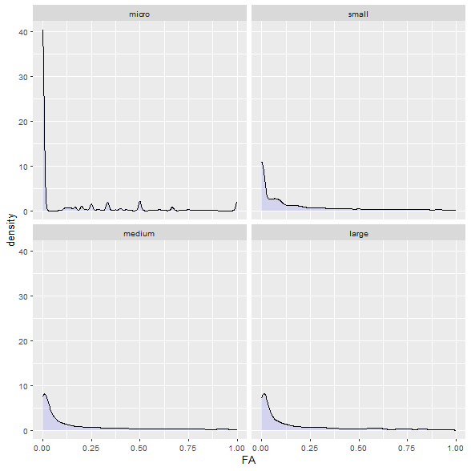

```r
#### plot sensitivity to XThreshold (double job months cutoff)
#### FA.orig : FA of jobs
#### FAe.orig: FA of employment/individuals
library(ggplot2)
library(cowplot)
#### Below gives an error: idvar need to specify unique rows
#### fadataiL <- reshape(fadatai[ii0 & !ii1, ],
####   direction = "long",
####   idvar = c("busdistmuni_geo", "buslocmuni_geo", "busmainplc_geo",
####     "Txrf", "payereferenceno"),
####   varying = grepout("^FA", colnames(fadatai))
#### )
#### MEMO: FA robustness to XThreshold (double-job month cutoff) was checked
#### visually via density plots of FA.orig, FA.25, FA.50, FA.75 in
#### CITIRP5BranchLevel.rmd L1300-1350. Conclusion to be confirmed.
#### IRP5HHI.rmd uses FA directly (no XThreshold loop applied here).
gsz <- ggplot(data = fadatai[ii0 & !ii1 & !is.na(Size), ],
  aes(x = FA)) + #### CLAUDE tpo:
  geom_density(alpha = .1, fill = "blue") +
  xlim(0, 1) +
  scale_color_manual(values = c("red", "blue"))
gsz <- gsz + facet_wrap(Size ~ .)
gsz
```

```r
ggsave(
   paste0(pathresults, "FAByFirmSize.jpg")
  , gsz, width = 8*2, height = 4*2, units = "cm",
  dpi = 300
 )
```

```
#> Removed 13136 rows containing non-finite outside the scale range (`stat_density()`).
```

```r
#### possible duplicates with different local municipality names
ii0 <- fadatai[, buslocmuni_geo != "" & busdistmuni_geo != ""
   & busmainplc_geo != ""]
ii1 <- duplicated(fadatai[, .(
   busmainplc_geo, Txrf
 )])
ii2 <- duplicated(fadatai[, .(
   busmainplc_geo, Txrf
 )], fromLast = T)
table(data.table(nonNA=ii0, duplicates=ii1))
```

```
#>        duplicates
#> nonNA     FALSE    TRUE
#>   FALSE  238548  282643
#>   TRUE   857882 3434968
```

```r
table(duplicated(fadatai[ii0 & !ii1, ]))
```

```
#>
#>  FALSE
#> 857882
```

```r
#### plot sensitivity to XThreshold (double job months cutoff)
library(ggplot2)
library(cowplot)
g1 <- ggplot(data = fadatai[ii0 & !ii1, ],
  aes(x = FA)) + #### CLAUDE tpo:
  geom_density(alpha = .1, fill = "blue") +
  ggtitle("Fraction of affected jobs")+
  scale_x_continuous(name = "fraction per firm", limits=c(0, 1)) +
  scale_color_manual(values = "blue")
g2 <- ggplot(data = fadatai[ii0 & !ii1, ],
  aes(x = FAe)) + #### CLAUDE tpo:
  geom_density(alpha = .1, fill = "blue") +
  ggtitle("Fraction of affected workers")+
  scale_x_continuous(name = "fraction per firm", limits=c(0, 1)) +
  scale_color_manual(values = "red")
gs <- plot_grid(
  g1, g2,
  labels = c('a.', 'b.'),
  align="h"
)
```

```
#> Removed 54474 rows containing non-finite outside the scale range (`stat_density()`).
#> Removed 41338 rows containing non-finite outside the scale range (`stat_density()`).
```

```r
gs
```

[figure not shown]

```r
ggsave(
  paste0(pathresults, "FAInJobsAndEmployment.jpg")
  , gs, width = 8*2, height = 4*2, units = "cm",
  dpi = 300
 )
```

```r
library(qs)
library(data.table)
library(ggplot2)
#### irp5Ma is created in
#### Location information granularity checks (next section)
#### irp5Ma <- qread(paste0(pathdata, "irp5Ma.qs"), nthreads = 13)
faa <- qread(paste0(pathsaveddata, "FAOfAgri.qs"),
  nthreads = DTThreads, use_alt_rep = TRUE) #### CLAUDE tpo:
#### Below is resolved. Negative duration reflects
#### "revision reporting to SARS" by firms.
#### To Michael, 2026 Jan 21, negative duration entries
#### FAD[, .(Num = .N, Neg = sum(DurMonthMarch<0)), by = (yr)][,
####  .(yr, Num, NegRate = round(Neg/Num, 4))]
geovars <- grepout("^bus.*geo$", colnames(faa))
faa[, Num := as.integer(.N), by = c(geovars, "taxrefno", "taxyear")]
irp5ForPlot <- unique(faa[taxyear >= 2010 & taxyear <= 2020,
  c(geovars, "taxyear", "taxrefno", "Num", "FA"), with = F]) #### CLAUDE tpo:
irp5ForPlot[, taxyear := as.character(taxyear)]
g1 <- ggplot(data = irp5ForPlot[busmainplc_geo != "", ],
    aes(x = Num, group = taxyear, colour = taxyear, fill = taxyear)) +
  geom_histogram(bins = 50) +
  scale_color_viridis_d("Tax year") +
  scale_fill_viridis_d() +
  scale_x_continuous(trans = "log10") +
  theme_bw() +
  theme(axis.text.x = element_text(angle = 90, vjust = .5)) + #### CLAUDE tpo:
  facet_wrap(taxyear ~ ., ncol = 2)
ggsave(
  paste0(pathresults, "NumberOfAgEmployees2010-2020.jpg")
  , g1, width = 8*2, height = 4*2, units = "cm",
  dpi = 300
 )
```

```r
#### irp5M, agriculture
#### Jobs by firm age (existed prior to 2013 vs. new entrants after 2013)
irp5Ma <- qread(paste0(pathdata, "irp5Ma.qs"),
  nthreads = DTThreads, use_alt_rep = TRUE)
irp5Ma[, .(num = 1:.N, Num), by = .(taxyear, taxrefno)][num == 1,
  .(TotalJobs = sum(Num, na.rm = T)), by = taxyear]
irp5Ma[, .(num = 1:.N, Num = .N), by = .(taxyear, taxrefno)][num == 1,
  .(TotalJobs = sum(Num, na.rm = T)), by = taxyear]
irp5Ma[, ExistedBefore2013 := as.integer(NA)]
irp5Ma[taxyear < 2013, ExistedBefore2013 := 1L]
irp5Ma[, ExistedBefore2013 := ExistedBefore2013[!is.na(ExistedBefore2013)][1], by = taxrefno]
irp5Ma[is.na(ExistedBefore2013), ExistedBefore2013 := 0L]
JobsFirms <- irp5Ma[, .(num = 1:.N, Num = .N),
  by = .(ExistedBefore2013, taxyear, taxrefno)][
  num == 1, .(TotalJobs = sum(Num, na.rm = T)), by = .(ExistedBefore2013, taxyear)]
JobsFirms[, Sample := "Entrants"]
JobsFirms[ExistedBefore2013 == 1L, Sample := "Incumbents"]
g1 <- ggplot(data = JobsFirms, aes(x = taxyear, y = TotalJobs)) +
  geom_col() +
  scale_x_continuous(breaks = 2009:2022) +
  facet_grid(~ Sample) +
  theme(axis.text.x = element_text(angle = 90, vjust = .5))
ggsave(
  paste0(pathresults, "NumberOfAgEmployees.jpg")
  , g1, width = 8*2, height = 4*2, units = "cm",
  dpi = 300
 )
```

```r
g2 <- ggplot(data = irp5ForPlot[busmainplc_geo != "", ],
    aes(x = FA, group = taxyear, colour = taxyear, fill = taxyear)) +
  geom_density(alpha = .3) +
  scale_color_viridis_d("Tax year") +
  scale_fill_viridis_d() +
  scale_x_continuous(limits = c(1, 100)) +
  theme_bw() +
  theme(axis.text.x = element_text(angle = 90, vjust = .5)) + #### CLAUDE tpo:
  facet_wrap(taxyear ~ ., ncol = 2)
ggsave(
  paste0(pathresults, "FAOfAg2010-2022.jpg")
  , g2, width = 8*2, height = 4*2, units = "cm",
  dpi = 300
 )
```

```
#> Removed 56184 rows containing non-finite outside the scale range (`stat_density()`).
```

```r
#### FA of agri
g2 <- ggplot(data = faa, aes(x = as.factor(taxyear), y = FA)) +
####  geom_point(size = .1, position = position_jitterdodge()) +
####  geom_point(data = faama, size = 1, fill = "blue")
  geom_boxplot(fill = "white", colour = "blue", outlier.alpha = 0) +
####  geom_jitter(width = .2) +
  scale_x_discrete(name = "Tax year") +
  facet_grid(~ Sample) +
  theme(axis.text.x = element_text(angle = 90, vjust = .5))
ggsave(
  paste0(pathresults, "FAOfAgri.jpg")
  , g2, width = 8*2, height = 4*2, units = "cm",
  dpi = 300
 )
```

```
#> Removed 1251 rows containing non-finite outside the scale range (`stat_boxplot()`).
```

# Location information granularity checks

We need to know how granular the location information is. Based on granularity, we decide at what level one can use the sampled firm.

```
irp5 (all firms, no filter; used for FA)
├── irp5M             Main Place    NARowsMai==0 & LocGranularFirm==Mai  |  NARowsMai>0 & MainPlNum==1
├── irp5L  (not M)    Local Muni    NARowsLoc==0 & LocGranularFirm==Loc  |  NARowsLoc>0 & LocMunNum==1
├── irp5D  (not M/L)  Dist Muni     NARowsDis==0 & LocGranularFirm==Dis  |  NARowsDis>0 & DisMunNum==1
├── irp5P  (not M/L/D) Province     NARowsPrv==0 & LocGranularFirm==Prv  |  NARowsPrv>0 & ProvNum==1
└── (remainder)                     location ambiguous or absent at all levels
```

Mutually exclusive by construction; firm-level (all rows travel together). `irp5` → FA; `irp5M` → HHI.

```r
rm(FAD); rm(Fadata); rm(fadata); rm(inda);
rm(faa)
gc()
```

|  | used | (Mb) | gc trigger | (Mb) | max used | (Mb) |
| --- | --- | --- | --- | --- | --- | --- |
| Ncells | 2.510706e+07 | 1.340900e+03 | 6.673239e+07 | 3.563900e+03 | 6.673239e+07 | 3.563900e+03 |
| Vcells | 7.025542e+09 | 5.360070e+04 | 2.190430e+10 | 1.671166e+05 | 1.822056e+10 | 1.390119e+05 |

```r
if (!exists("RunSep")) RunSep <- T
if (RunSep || length(ls(pattern="^irp5$"))==0)
  irp5 <- qread(paste0(pathsaveddata, "irp5.qs"),
    nthreads = DTThreads, use_alt_rep = TRUE)
geoLevel <- c("Prv", "Dis", "Loc", "Mai")
geovars <- grepout("^bus.*geo$", colnames(irp5))
#### Location granularity indicator
#### irp5[, LocGranular := "none"]
#### CLAUDE opt: replaced 15-year × 4-level loop (60 full-table scans) with a single
####   fcase() pass grouped by (Txrf, taxyear). any() evaluates group-wide and fcase()
####   short-circuits; semantics identical — all rows of a qualifying (Txrf, yr) group
####   get the same level as before.
#### for (yr in 8:22) {
####   irp5[Txrf %in% Txrf
####     [busprov_geo != "" & busdistmuni_geo != "" &
####      buslocmuni_geo != "" & busmainplc_geo != "" & taxyear == 2000 + yr] &
####     taxyear == 2000 + yr, LocGranular := GeoLevel[4]]
####   irp5[Txrf %in% Txrf
####     [busprov_geo != "" & busdistmuni_geo != "" &
####      buslocmuni_geo != "" & busmainplc_geo == "" & taxyear == 2000 + yr] &
####     taxyear == 2000 + yr, LocGranular := GeoLevel[3]]
####   irp5[Txrf %in% Txrf
####     [busprov_geo != "" & busdistmuni_geo != "" &
####      buslocmuni_geo == "" & busmainplc_geo == "" & taxyear == 2000 + yr] &
####     taxyear == 2000 + yr, LocGranular := GeoLevel[2]]
####   irp5[Txrf %in% Txrf
####     [busprov_geo != "" & busdistmuni_geo == "" &
####      buslocmuni_geo == "" & busmainplc_geo == "" & taxyear == 2000 + yr] &
####     taxyear == 2000 + yr, LocGranular := GeoLevel[1]]
#### }
#### CLAUDE opt: pre-compute existence flags per (Txrf, taxyear); avoids
####   repeating the full any() condition 4x per level; fcase() then uses
####   simple logical ops with no by= (flags already per-row constants)
#### !is.na() is required: without it, a group with only NA/empty geo values
####   gives any(NA) = NA instead of FALSE, breaking fcase() assignment.
####   Trace for x <- c(NA, "", "") (no valid entry in group):
####   x != ""           → c(NA,    FALSE, FALSE)
####   !is.na(x)         → c(FALSE, TRUE,  TRUE)
####   so far            → c(FALSE, FALSE, FALSE)
####   !grepl("EXCEP",x) → c(NA,    TRUE,  TRUE)
####   element-wise &    → c(FALSE, FALSE, FALSE)
####   any(...)          → FALSE  ← CORRECT; without !is.na(): any(c(NA,F,F)) = NA
irp5[, c("provexists", "distexists", "locexists", "mainexists") := .(
  any(busprov_geo     != "" & !is.na(busprov_geo)     & !grepl("EXCEP", busprov_geo)),
  any(busdistmuni_geo != "" & !is.na(busdistmuni_geo) & !grepl("EXCEP", busdistmuni_geo)),
  any(buslocmuni_geo  != "" & !is.na(buslocmuni_geo)  & !grepl("EXCEP", buslocmuni_geo)),
  any(busmainplc_geo  != "" & !is.na(busmainplc_geo)  & !grepl("EXCEP", busmainplc_geo))
), by = .(Txrf, taxyear)]
irp5[, LocGranular := fcase(
  #### Granular down to Main Place
   provexists &  distexists &  locexists &  mainexists, GeoLevel[4],
  #### Granular down only to Loc muni
   provexists &  distexists &  locexists & !mainexists, GeoLevel[3],
  #### Granular down only to Dist muni
   provexists &  distexists & !locexists & !mainexists, GeoLevel[2],
  #### Granular down only to Province
   provexists & !distexists & !locexists & !mainexists, GeoLevel[1],
  default = "none"
)]
#### LocGranular = Main, Loc, Dist, Prov are all exclusive
####   LocGranular == Main group has info of Prov
####   but is not included in LocGranular = Prov group
irp5[, c("provexists", "distexists", "locexists", "mainexists") := NULL]
irp5[, LocGranular := factor(LocGranular, levels = c(GeoLevel, "none"))]
#### LocGranularFirm: Most granular location info (order sensitive)
#### LocGranularJob: Most granular location info (order insensitive)
setnames(irp5, "LocGranular", "LocGranularFirm")
irp5[, LocGranularJob := "none"]
irp5[busprov_geo != "", LocGranularJob := GeoLevel[1]]
irp5[busdistmuni_geo != "", LocGranularJob := GeoLevel[2]]
irp5[buslocmuni_geo != "", LocGranularJob := GeoLevel[3]]
irp5[busmainplc_geo != "", LocGranularJob := GeoLevel[4]]

#### Location granularity due to establishment clustering
#### When location info is missing in some rows, one can allocate workers
#### only up to location level where all establishments are clustered
for (mm in 1:length(GeoLevel)) {
  irp5[, (GeoLevel[mm]) := get(geovars[mm])]
  irp5[get(geovars[mm]) == "", (GeoLevel[mm]) := NA]
}
#### Number of unique entries at each level
#### Subtract 1 because NA is counted as 1 (all NA entries are MainPlNum == 1L)
#### irp5[, MainPlNum := as.integer(length(unique(Mai)))-1L, by = .(Txrf, taxyear)]
#### CLAUDE opt: uniqueN() is data.table-native; avoids length(unique()) overhead;
####   returns integer already so as.integer() wrapper dropped. -1L correction
####   unchanged: NA counts as 1 distinct value in both uniqueN() and unique().
irp5[, MainPlNum := uniqueN(Mai)-1L, by = .(Txrf, taxyear)]
#### irp5[, LocMunNum := as.integer(length(unique(Loc)))-1L, by = .(Txrf, taxyear)]
#### CLAUDE opt:
irp5[, LocMunNum := uniqueN(Loc)-1L, by = .(Txrf, taxyear)]
#### irp5[, DisMunNum := as.integer(length(unique(Dis)))-1L, by = .(Txrf, taxyear)]
#### CLAUDE opt:
irp5[, DisMunNum := uniqueN(Dis)-1L, by = .(Txrf, taxyear)]
#### irp5[, ProvNum   := as.integer(length(unique(Prv)))-1L, by = .(Txrf, taxyear)]
#### CLAUDE opt:
irp5[, ProvNum   := uniqueN(Prv)-1L, by = .(Txrf, taxyear)]
irp5[, MainPlNA := as.integer(all(is.na(Mai))), by = .(Txrf, taxyear)]
irp5[, LocMunNA := as.integer(all(is.na(Loc))), by = .(Txrf, taxyear)]
irp5[, DisMunNA := as.integer(all(is.na(Dis))), by = .(Txrf, taxyear)]
irp5[, ProvNA := as.integer(all(is.na(Prv))), by = .(Txrf, taxyear)]

irp5[, CommonLocality := "none"]
irp5[
      ProvNum == 1L &
    DisMunNum == 1L &
    LocMunNum == 1L &
    MainPlNum == 1L &
    MainPlNA  == 0L,
  CommonLocality := GeoLevel[4]]
irp5[
    ProvNum   == 1L &
    DisMunNum == 1L &
    LocMunNum == 1L &
    MainPlNum != 1L &
    LocMunNA  == 0L,
  CommonLocality := GeoLevel[3]]
irp5[
    ProvNum   == 1L &
    DisMunNum == 1L &
    LocMunNum != 1L &
    MainPlNum != 1L &
    DisMunNA  == 0L,
  CommonLocality := GeoLevel[2]]
irp5[
    ProvNum   == 1L &
    DisMunNum != 1L &
    LocMunNum != 1L &
    MainPlNum != 1L &
    ProvNA  == 0L,
  CommonLocality := GeoLevel[1]]
irp5[, CommonLocality := factor(CommonLocality, levels = c(GeoLevel, "none"))]
irp5[, NARowsMai := as.integer(sum(is.na(Mai))), by = .(Txrf, taxyear)]
irp5[, NARowsLoc := as.integer(sum(is.na(Loc))), by = .(Txrf, taxyear)]
irp5[, NARowsDis := as.integer(sum(is.na(Dis))), by = .(Txrf, taxyear)]
irp5[, NARowsPrv := as.integer(sum(is.na(Prv))), by = .(Txrf, taxyear)]
irp5[, TotalRowsInTxrf := as.integer(.N), by = .(Txrf, taxyear)]
qsave(irp5, paste0(pathdata, "irp5_LocationGranularity.qs"),
  nthreads = DTThreads)

unique(irp5[Txrf %in% Txrf[grepl("^M", LocGranularFirm) | grepl("^M", CommonLocality)][1]
  & taxyear == 2009,
  c("Txrf", "UID", geovars, grepout("Num|Rows|Gran|Commo", colnames(irp5))), with = F])
```

| Txrf | UID | busprov_geo | busdistmuni_geo | buslocmuni_geo | busmainplc_geo | Num | LocGranularFirm | LocGranularJob | MainPlNum | LocMunNum | DisMunNum | ProvNum | CommonLocality | NARowsMai | NARowsLoc | NARowsDis | NARowsPrv | TotalRowsInTxrf |
| --- | --- | --- | --- | --- | --- | --- | --- | --- | --- | --- | --- | --- | --- | --- | --- | --- | --- | --- |
| AACAAAXGCC | QXCGACCCACBBG |  |  |  |  | 2 | Mai | none | 1 | 1 | 1 | 1 | Mai | 1 | 1 | 1 | 1 | 2 |
| AACAAAXGCC | BXCCZCTKCKCTK | Western Cape | City of Cape Town | City of Cape Town | Durbanville | 2 | Mai | Mai | 1 | 1 | 1 | 1 | Mai | 1 | 1 | 1 | 1 | 2 |